# C53 project Part2-contingency table and plots -BoHan Wang

```r
library(tidyverse)
```

```r
my_url <- "http://sda.chass.utoronto.ca/sdaweb/tmpdir/AAULeQLH.csv"
my_data <- read_csv(my_url)
my_data
```

| CASEID | gtr | mtinc | ttinc |
| --- | --- | --- | --- |
| 2129 | 12600 | 46000 | 58600 |
| 2129 | 19825 | 7750 | 27575 |
| 2129 | 99999996 | 99999996 | 99999996 |
| 2129 | 99999996 | 99999996 | 99999996 |
| 2130 | 14250 | 0 | 14250 |
| 2130 | 4575 | 46000 | 50575 |
| 2130 | 99999996 | 99999996 | 99999996 |
| 2130 | 99999996 | 99999996 | 99999996 |
| 2130 | 99999996 | 99999996 | 99999996 |
| 2131 | 23350 | 12500 | 35850 |

[output cut: 990 more lines]

This is the 2016 data of income which included goverment transfer, market income and total income. The 99999996 is the outlier which either they did not provide the data or they have an out balanced data. On the other hand, by the equation total income = government transfer + market income, 99999996 does not satisfy the equation.

```r
set.seed(1003287338)
row_sub = apply(my_data, 1, function(row) all(row !=99999996))
final <- my_data[row_sub,]
final %>% sample_n(1000) -> data
data
```

| CASEID | gtr | mtinc | ttinc |
| --- | --- | --- | --- |
| 3900 | 3200 | 0 | 3200 |
| 24360 | 0 | 52500 | 52500 |
| 3543 | 0 | 67500 | 67500 |
| 15178 | 12175 | 43000 | 55175 |
| 6063 | 21900 | 12250 | 34150 |
| 27200 | 0 | 92400 | 92400 |
| 23960 | 650 | 19500 | 20150 |
| 3971 | 12250 | 16500 | 28750 |
| 22348 | 3750 | 75000 | 78750 |
| 11148 | 0 | 75000 | 75000 |

[output cut: 990 more lines]

This function removes all the outliers that have income value of 99999996. Also, randomly sample 1000 rows of CASEID, the set seed assures that any randomsample has a boundary.

```r
gtrcount = 0
mtinccount = 0
totalcount = 0
for (i in data$gtr){
  if (i == 0){
    gtrcount = gtrcount+1
  }
}
for (i in data$mtinc){
  if (i == 0){
    mtinccount = mtinccount+1
  }
}
for (i in data$ttinc){
  if (i == 0){
    totalcount = totalcount+1
  }
}
c("gtrcount"=gtrcount, "mtinccount"=mtinccount, "totalcount"=totalcount)
```

```
  gtrcount mtinccount totalcount
       285        118         21
```

This function counts all the 0s in government tranfer, marketincome and total income. This data is used to construct a contingency table for further analysis.

```r
table1 <- array(data = c(1000-totalcount-(gtrcount-totalcount)-(mtinccount-totalcount),
                         gtrcount-totalcount,
                         mtinccount-totalcount,
                         totalcount),
                dim = c(2,2),
                dimnames = list(Government = c("Yes","No"), Market = c("Yes","No"))
                )
table1
```

```
          Market
Government Yes No
       Yes 618 97
       No  264 21
```

This contengency table shows the number of cases that: case1: neither of government transfer or market income equal to 0; case2: marketincome not equalto 0|government transfer equal to 0; case3: government transfer not equal to 0|market income equal to 0; case4: both government transfer and market income are 0.

```r
chisq.test(table1, correct = F)
```

```
    Pearson's Chi-squared test

data:  table1
X-squared = 7.5215, df = 1, p-value = 0.006097
```

```r
chisq.test(table1, correct = F)$expected
```

```
          Market
Government    Yes    No
       Yes 630.63 84.37
       No  251.37 33.63
```

These functions calculates the chisquare and display the expected values of the contingency table (where expected value equal to the product of row proportion, column proportion and total sum n). In the data, the p-value is 0.006097 which is strictly less than 0.05. This indicates that there exist interaction/association between government transfer and market income. Since the sample size is 1000 which is large sample, thus the Ei(expected values of each cell) is greater than 5.

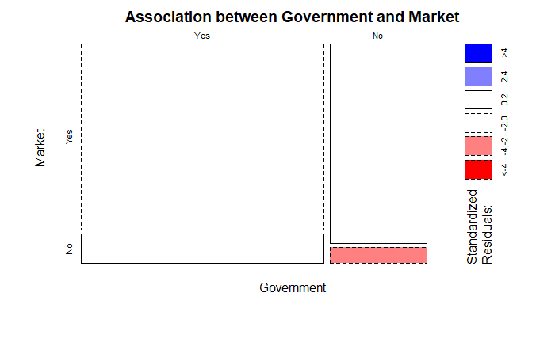

```r
table1 %>% mosaicplot(., main = "Association between Government and Market", shade = TRUE)
```

This function draws a mosaic plot of the contingency table. In this case, the table indicates that the sampled model is a good model since there’s only a small portion of the table is in the range from -4 to -2.

```r
chisq.test(table1, correct = F)$residuals # standarized
```

```
          Market
Government        Yes        No
       Yes -0.5029398  1.375021
       No   0.7966116 -2.177910
```

```r
chisq.test(table1, correct = F)$stdres # agjusted standarized
```

```
          Market
Government       Yes        No
       Yes -2.742538  2.742538
       No   2.742538 -2.742538
```

These functions display the standarized residual and adjusted standarizwed residual of the contingency table. Since both data does not have a cell that has value less than -3 or greater than 3. Thus, the mosiac plot above is a good plot.

```r
prop.test(c(618,264),c(618+97, 264+21),correct=F)
```

```
    2-sample test for equality of proportions without continuity correction

data:  c(618, 264) out of c(618 + 97, 264 + 21)
X-squared = 7.5215, df = 1, p-value = 0.006097
alternative hypothesis: two.sided
95 percent confidence interval:
 -0.10135004 -0.02261021
sample estimates:
   prop 1    prop 2
0.8643357 0.9263158
```

This function calcualtes the proportion of case1 and case2 with assumption of that case1 have the same proportions in respect to case2. The p-value is 0.006097 which is strictly less than 0.05 which indicates that case1 and case2 are not equal in proportion.

```r
url <- "http://sda.chass.utoronto.ca/sdaweb/tmpdir/AA6zjF2F.csv"
data <- read_csv(url)
data
```

| CASEID | earng | inva | mtinc | othinc | prpen |
| --- | --- | --- | --- | --- | --- |
| 2129 | 46000 | 0 | 46000 | 0 | 0 |
| 2129 | 0 | 0 | 7750 | 0 | 7750 |
| 2129 | 99999996 | 99999996 | 99999996 | 99999996 | 99999996 |
| 2129 | 99999996 | 99999996 | 99999996 | 99999996 | 99999996 |
| 2130 | 0 | 0 | 0 | 0 | 0 |
| 2130 | 46000 | 0 | 46000 | 0 | 0 |
| 2130 | 99999996 | 99999996 | 99999996 | 99999996 | 99999996 |
| 2130 | 99999996 | 99999996 | 99999996 | 99999996 | 99999996 |
| 2130 | 99999996 | 99999996 | 99999996 | 99999996 | 99999996 |
| 2131 | 12500 | 0 | 12500 | 0 | 0 |

[output cut: 990 more lines]

This data is also took from the 2016 economic data set.

```r
set.seed(1003287338)
row_sub = apply(data, 1, function(row) all(row !=99999996))
final <- data[row_sub,]
final %>% sample_n(1000) -> data3
data3
```

| CASEID | earng | inva | mtinc | othinc | prpen |
| --- | --- | --- | --- | --- | --- |
| 3900 | 0 | 0 | 0 | 0 | 0 |
| 24360 | 52500 | 0 | 52500 | 0 | 0 |
| 3543 | 67500 | 0 | 67500 | 0 | 0 |
| 15178 | 43000 | 0 | 43000 | 0 | 0 |
| 6063 | 12250 | 0 | 12250 | 0 | 0 |
| 27200 | 95000 | -2600 | 92400 | 0 | 0 |
| 23960 | 19500 | 0 | 19500 | 0 | 0 |
| 3971 | 0 | 0 | 16500 | 0 | 16500 |
| 22348 | 75000 | 0 | 75000 | 0 | 0 |
| 11148 | 75000 | 0 | 75000 | 0 | 0 |

[output cut: 990 more lines]

Use the same procedure from before to filter the data such that the outliers are eliminated.

```r
data3 %>% select(CASEID, earng, inva, othinc, prpen) %>% pivot_longer(earng:prpen, names_to = "inctype", values_to = "value") -> data4
data4
```

| CASEID | inctype | value |
| --- | --- | --- |
| 3900 | earng | 0 |
| 3900 | inva | 0 |
| 3900 | othinc | 0 |
| 3900 | prpen | 0 |
| 24360 | earng | 52500 |
| 24360 | inva | 0 |
| 24360 | othinc | 0 |
| 24360 | prpen | 0 |
| 3543 | earng | 67500 |
| 3543 | inva | 0 |

[output cut: 990 more lines]

This function convert the data such that all groups are collected as a categorical variable and all values are collected as quantitative variable.

We would like to compare means between each group, however t-test only compare 2 groups. If we do multiple t-test to compare between each 2 groups, that would violate the meaning of level of significance. Thus there’s a method to adjust all the comparisons of the mean of each groups (which is named Tukey). Tukey compares all several groups at once and tells you which group is differ from which.

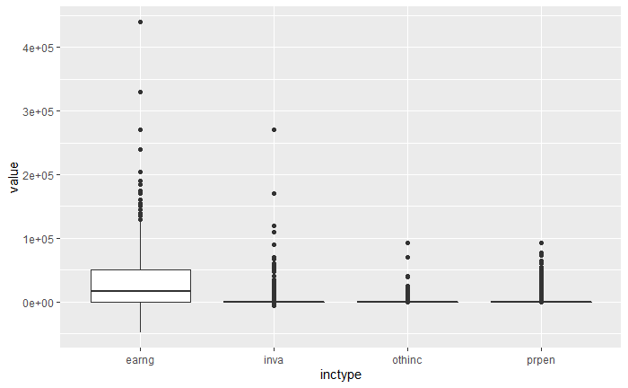

```r
data4 %>% ggplot(aes(x=inctype, y=value)) + geom_boxplot()
```

The assumption of this test is that the data is normally distributed with equal spread. The data in boxplot does not support the assumption of equal spread in this case. There’s another Tukey’s equivalent is named Games-Howell which the assumptions are that the data is normally distributed with not equal spread.

```r
library(devtools)
install_github("nxskok/smmr")
```

[output not shown]

```r
library(PMCMRplus)
```

These packages’ copyright belongs to Ken Butler. The package contains the Tukey’s test and many more tests that are useful.

```r
gamesHowellTest(value~factor(inctype), data=data4)
```

```
    Pairwise comparisons using Games-Howell test

data: value by factor(inctype)
```

```
       earng   inva   othinc
inva   < 2e-16 -      -
othinc 9.3e-14 0.0012 -
prpen  < 2e-16 0.4306 1.4e-12
```

```
P value adjustment method: none
alternative hypothesis: two.sided
```

This test gives the follow conditions based on p-values: - earning differ from investment income - earning differ from other income - earning differ from private pension plan - investment income differ from other income - other income differ from private pension plan

```r
data3 %>% summary()
```

```
     CASEID          earng             inva            mtinc            othinc            prpen
 Min.   : 2135   Min.   :-48000   Min.   : -6750   Min.   : -7150   Min.   :    0.0   Min.   :    0
 1st Qu.: 9342   1st Qu.:     0   1st Qu.:     0   1st Qu.:  6950   1st Qu.:    0.0   1st Qu.:    0
 Median :15699   Median : 17125   Median :     0   Median : 27000   Median :    0.0   Median :    0
 Mean   :15761   Mean   : 31176   Mean   :  2627   Mean   : 38114   Mean   :  838.5   Mean   : 3471
 3rd Qu.:22532   3rd Qu.: 50000   3rd Qu.:    50   3rd Qu.: 55000   3rd Qu.:    0.0   3rd Qu.:    0
 Max.   :28800   Max.   :440000   Max.   :270000   Max.   :440350   Max.   :92500.0   Max.   :92500
```